# Project 1 - Clean/Train Housing Dataset

By Christian Garzon

# Intro

For my Project I plan on attempting to train a model in hopes of predicting the Sale Price of the houses. In order to do this I will first clean as much of the data as possible and pick certain variables to train the model on depending on each variables predicting power (correlation w/ Sale Price). My focus will be on the data wrangling and cleaning, trying different methods to try to make the data as clean as possible without changing too much about the original data. After I do this I will choose the best predictors and attempt to create a model using these predictors, in doing so I should be able to predict a house value within a reasonable margin of error.

# Set Up

```python
# Import the necessary libraries for machine learning linear regression
import pandas as pd
import numpy as np
import matplotlib.pyplot as plt
import seaborn as sns
from sklearn.linear_model import LinearRegression
from sklearn.model_selection import train_test_split, cross_val_score
from sklearn.metrics import r2_score, mean_squared_error
from sklearn.preprocessing import StandardScaler

# Setting up the plot style
plt.style.use('default')
plt.rcParams['figure.figsize'] = (10, 6)
plt.rcParams['font.size'] = 12

# Mount Google Drive
from google.colab import drive
drive.mount('/content/drive')

# Upload Housing Dateset
data = pd.read_csv('/content/drive/My Drive/Foundations of Data Science/Data Set/ames-housing-train.csv')
print(f"Dataset shape: {data.shape}")
data.head()
```

```
Dataset shape: (1460, 81)
```

|  | Id | MSSubClass | MSZoning | LotFrontage | LotArea | Street | Alley | LotShape | LandContour | Utilities | ... | PoolArea | PoolQC | Fence | MiscFeature | MiscVal | MoSold | YrSold | SaleType | SaleCondition | SalePrice |
| --- | --- | --- | --- | --- | --- | --- | --- | --- | --- | --- | --- | --- | --- | --- | --- | --- | --- | --- | --- | --- | --- |
| 0 | 1 | 60 | RL | 65.0 | 8450 | Pave | NaN | Reg | Lvl | AllPub | ... | 0 | NaN | NaN | NaN | 0 | 2 | 2008 | WD | Normal | 208500 |
| 1 | 2 | 20 | RL | 80.0 | 9600 | Pave | NaN | Reg | Lvl | AllPub | ... | 0 | NaN | NaN | NaN | 0 | 5 | 2007 | WD | Normal | 181500 |
| 2 | 3 | 60 | RL | 68.0 | 11250 | Pave | NaN | IR1 | Lvl | AllPub | ... | 0 | NaN | NaN | NaN | 0 | 9 | 2008 | WD | Normal | 223500 |
| 3 | 4 | 70 | RL | 60.0 | 9550 | Pave | NaN | IR1 | Lvl | AllPub | ... | 0 | NaN | NaN | NaN | 0 | 2 | 2006 | WD | Abnorml | 140000 |
| 4 | 5 | 60 | RL | 84.0 | 14260 | Pave | NaN | IR1 | Lvl | AllPub | ... | 0 | NaN | NaN | NaN | 0 | 12 | 2008 | WD | Normal | 250000 |

5 rows × 81 columns

# Cleaning the Data

To train the model I must first clean up a lot of the data. I will do this by looking at all the missing data and trying to find if there is a reason for the data to be missing or if the it is at random. I will do this by counting all the NaN in each variable and creating a list of each variable containing missing data.

[Kaggle Dataset](https://www.kaggle.com/competitions/house-prices-advanced-regression-techniques/data)

```python
missing_data = data.isnull().sum()
missing_data = missing_data.sort_values(ascending=False)
missing_data = missing_data[missing_data > 0]
missing_data
```

|  | 0 |
| --- | --- |
| PoolQC | 1453 |
| MiscFeature | 1406 |
| Alley | 1369 |
| Fence | 1179 |
| MasVnrType | 872 |
| FireplaceQu | 690 |
| LotFrontage | 259 |
| GarageQual | 81 |
| GarageFinish | 81 |
| GarageType | 81 |
| GarageYrBlt | 81 |
| GarageCond | 81 |
| BsmtFinType2 | 38 |
| BsmtExposure | 38 |
| BsmtCond | 37 |
| BsmtQual | 37 |
| BsmtFinType1 | 37 |
| MasVnrArea | 8 |
| Electrical | 1 |

**dtype:** int64

The missing data found in the dataset can be found in the following variables:

- LotFrontage: Linear feet of street connected to property
- Alley: Type of alley access
- MasVnrType: Masonry veneer type
- MasVnrArea: Masonry veneer area in square feet
- BsmtQual: Height of the basement
- BsmtCond: General condition of the basement
- BsmtExposure: Walkout or garden level basement walls
- BsmtFinType1: Quality of basement finished area
- BsmtFinType2: Quality of second finished area (if present)
- Electrical: Electrical system
- FireplaceQu: Fireplace quality
- GarageType: Garage location
- GarageYrBlt: Year garage was built
- GarageFinish: Interior finish of the garage
- GarageQual: Garage quality
- GarageCond: Garage condition
- PoolQC: Pool quality
- Fence: Fence quality
- MiscFeature: Miscellaneous feature not covered in other categories

## Electrical

Some of the data can be easily cleaned, such as the electrical which we can just drop without changing the overall quality of the dataset

```python
print(f"Shape before dropping: {data.shape}")
data.dropna(subset=['Electrical'], inplace=True)
print(f"Shape after dropping: {data.shape}")
```

```
Shape before dropping: (1460, 81)
Shape after dropping: (1459, 81)
```

### Testin Electrical Correlation

```
['SBrkr' 'FuseF' 'FuseA' 'FuseP' 'Mix']
```

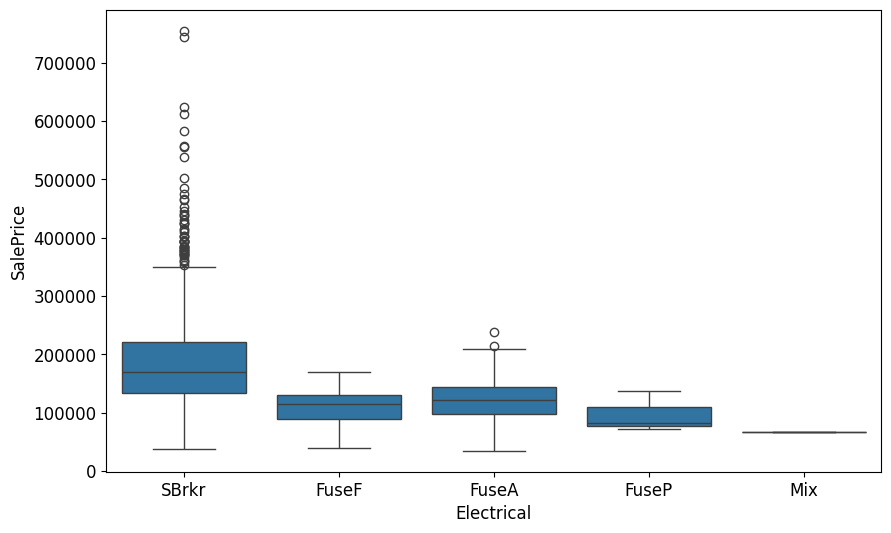

```python
print(data['Electrical'].unique())

# Creating a visualization to hopefully recognize pattern and assign numerical values for the different types of Electrical types
sns.boxplot(x='Electrical', y='SalePrice', data=data)
```

```python
#Trying to assign numerical values from best to worst based off the graph above

data['Electrical'] = data['Electrical'].replace('SBrkr', 5)

data['Electrical'] = data['Electrical'].replace('FuseA', 4)

data['Electrical'] = data['Electrical'].replace('FuseF', 3)

data['Electrical'] = data['Electrical'].replace('FuseP',2)

data['Electrical'] = data['Electrical'].replace('Mix',1)

print(data['Electrical'].unique())
```

```
[5 3 4 2 1]
```

```python
print(data['SalePrice'].corr(data['Electrical']))
```

```
0.23358995500623655
```

Although my assumption for the values of each category was very crude and purely assumption based, I believe that there isn't enough variation within each category to have a significant correlation with the housing price. Im just going to drop this whole category to help make the dataset more simple, I will continue doing this going forward, for any category that doesn't seem to have much correlation with the housing price I will drop to increase dataset simplicity.

```python
data = data.drop(columns=['Electrical'])
```

## PoolQC

Other variables we must first investigate the missing data and then decide how to handle it, such as the PoolQC variable

```python
# Finding the index for the houses which have a pool (Pool Area > 0)
realPool = data[data['PoolArea'] > 0]
print(realPool.index)

# Finding the index for the houses which Pool Qalitiy is not 'NaN'
realPoolQC = data[data['PoolQC'].notnull()]
print(realPoolQC.index)
```

```
Index([197, 810, 1170, 1182, 1298, 1386, 1423], dtype='int64')
Index([197, 810, 1170, 1182, 1298, 1386, 1423], dtype='int64')
```

Since the index is the same for both houses with pools and houses that have a reported Pool Quality data, we can assume that the rest of Pool Quality data is missing because no pool exists. Thus we can replace these variables with 'No Pool'

```python
# Printing the current element listings of a variable
print(f"PoolQC elements before cleaning: {data['PoolQC'].unique()}")

# Taking out the 'NaN' Elements and replacing with 'No Pool'
data['PoolQC'] = data['PoolQC'].fillna('No Pool')

# Looking at the new element listings of a variable
print()
print(f"PoolQC elements after cleaning: {data['PoolQC'].unique()}")
```

```
PoolQC elements before cleaning: [nan 'Ex' 'Fa' 'Gd']

PoolQC elements after cleaning: ['No Pool' 'Ex' 'Fa' 'Gd']
```

### Testing Pool Correlation

```python
data['PoolQC'] = data['PoolQC'].replace('No Pool', 1)

data['PoolQC'] = data['PoolQC'].replace('Gd', 2)

data['PoolQC'] = data['PoolQC'].replace('Fa', 3)

data['PoolQC'] = data['PoolQC'].replace('Ex',4)

print(data['PoolQC'].unique())
```

```
[1 4 3 2]
```

```python
print(data['SalePrice'].corr(data['PoolQC']))
print(data['SalePrice'].corr(data['PoolArea']))
```

```
0.12606381289804042
0.09239664651115574
```

I wasn't expecting this to be too high of a correlation since so many houses don't have pools. Since the correlation is low I will just drop all the pool categories.

```python
data = data.drop(columns=['PoolQC'])
data = data.drop(columns=['PoolArea'])

data.shape
```

```
(1459, 78)
```

## Fireplace

A similar process can be done for Fireplace Quality

```python
# Creating a dataframe for the houses with no fireplace (Fireplaces = 0)
noFireplace = data[data['Fireplaces']==0]

# Creating a dataframe for houseing with no fireplace and where fireplace quality is null
noFireplace_qual = data[(data['FireplaceQu'].isnull()) & (data['Fireplaces'] == 0)]

print(f"Shape of data with no Fireplace: {noFireplace.shape}")

print(f"Shape of data with no Fireplace and no Fireplace Quality: {noFireplace_qual.shape}")
```

```
Shape of data with no Fireplace: (689, 78)
Shape of data with no Fireplace and no Fireplace Quality: (689, 78)
```

Since these have the same shape, then that means Fireplace Quality is null when there is no Fireplace, so we can replace the nulls with 'No Fireplace'

```python
data['FireplaceQu'] = data['FireplaceQu'].fillna('No Fireplace')
```

### Testing Fireplace Correlation

```python
print(data['FireplaceQu'].unique())
```

```
['No Fireplace' 'TA' 'Gd' 'Fa' 'Ex' 'Po']
```

```python
data['FireplaceQu'] = data['FireplaceQu'].replace('No Fireplace', 1)

data['FireplaceQu'] = data['FireplaceQu'].replace('Po', 2)

data['FireplaceQu'] = data['FireplaceQu'].replace('Fa', 3)

data['FireplaceQu'] = data['FireplaceQu'].replace('TA',4)

data['FireplaceQu'] = data['FireplaceQu'].replace('Gd',5)

data['FireplaceQu'] = data['FireplaceQu'].replace('Ex',6)

print(data['FireplaceQu'].unique())
```

```
[1 4 5 3 6 2]
```

```python
print(data['SalePrice'].corr(data['FireplaceQu']))
print(data['SalePrice'].corr(data['Fireplaces']))
```

```
0.5205072958450776
0.46696804555163896
```

Since both of these have a decent correlation I am inclined to keep them in the dataset, however since they might be highly correlated with each other since they are both related to fireplaces I fear creating noise during the training process. To avoid this I have decided for categories that are highly related, meaning if they are about similar features, I will only choose the category that has the most correlation to keep my dataset more simple. Although this is probably not the preferred method this will help keep the process and dataset more simple.

Based off their correlations with sale price it seems quality has a higher predicitive power than quantity so I will keep quality.

```python
data = data.drop(columns = ['Fireplaces'])

data.shape
```

```
(1459, 77)
```

## Misc Features

This process can be repeated for Misc Features

```python
# Creating a list of all the Miscellaneous items which have a value greater than 0
realMiscVal = data[data['MiscVal'] > 0]
print(realMiscVal.shape)

# Creating a list of all the Miscellaneous items which which are not null
realMiscFeature = data[data['MiscFeature'].notnull()]
print(realMiscFeature.shape)
```

```
(52, 77)
(54, 77)
```

Since the shapes of the dataframes don't line up, then there must be an item which exists has a value of 0.

To ensure this only happens once and theres no other discreprencies I first compare the ids from the Miscellaneous items with value and compare it to the ids of all existing miscellaneous items.

Then I double check for the two extra rows in miscellaneous items, that they have a value of 0.

```python
# Comparing the Ids in both lists, and adding any possible discreprencies to missingVal
missingVal = realMiscVal[~realMiscVal['Id'].isin(realMiscFeature['Id'])]['Id'].tolist()
print("IDs with MiscVal > 0 but null MiscFeature:", missingVal)

print()

# Making sure the two extra rows have a value of 0
extra_feature_rows = data[(data['MiscFeature'].notnull()) & (data['MiscVal'] == 0)]
print(extra_feature_rows.shape)
print(extra_feature_rows[['MiscFeature', 'MiscVal']].head())
```

```
IDs with MiscVal > 0 but null MiscFeature: []

(2, 77)
     MiscFeature  MiscVal
873         Othr        0
1200        Shed        0
```

```python
# Printing the current element listings of a variable
print(f"MiscFeature elements before cleaning: {data['MiscFeature'].unique()}")

# Taking out the 'NaN' Elements and replacing with 'No Feature'
data['MiscFeature'] = data['MiscFeature'].fillna('No Feature')

# Looking at the new element listings of a variable
print()
print(f"MiscFeature elements after cleaning: {data['MiscFeature'].unique()}")
```

```
MiscFeature elements before cleaning: [nan 'Shed' 'Gar2' 'Othr' 'TenC']

MiscFeature elements after cleaning: ['No Feature' 'Shed' 'Gar2' 'Othr' 'TenC']
```

### Testing Misc Features Correlation

Since Misc Features is just categorical values with no inherent numerical conversion I will first test the Misc Value correlation. If there is no strong correlation I will just drop both Misc categories, if there is a strong correlation I will do deeper digging into the Misc Features.

```python
print(data['SalePrice'].corr(data['MiscVal']))
```

```
-0.021200000137796094
```

No strong correlation so I will just drop both Misc columns

```python
data = data.drop(columns=['MiscVal'])
data = data.drop(columns=['MiscFeature'])

data.shape
```

```
(1459, 75)
```

## Garage Variables

- GarageType: Garage location
- GarageYrBlt: Year garage was built
- GarageFinish: Interior finish of the garage
- GarageArea: Size of garage in square feet
- GarageQual: Garage quality
- GarageCond: Garage condition

To ensure they are the same data points I will check the shape of a dataframe made of two variables at once. If the shape remains the same then they are the same missing values, if the shapes are not equal then they have different missing values.

```python
noGarage = data[data['GarageArea']==0]

print(f"The Shape of data with no Garage: {noGarage.shape}")

print()

noGarage_Type = data[(data['GarageType'].isnull()) & (data['GarageArea'] == 0)]

print(f"The Shape of data with no Garage and no Garage Type: {noGarage_Type.shape}")

noGarage_YrBlt = data[(data['GarageYrBlt'].isnull()) & (data['GarageArea'] == 0)]

print()

print(f"The Shape of data with no Garage and no Year Built: {noGarage_YrBlt.shape}")

noGarage_Finish = data[(data['GarageFinish'].isnull()) & (data['GarageArea'] == 0)]

print()

print(f"The Shape of data with no Garage and no interior Finish: {noGarage_Finish.shape}")

noGarage_Qual = data[(data['GarageQual'].isnull()) & (data['GarageArea'] == 0)]

print()

print(f"The Shape of data with no Garage and no quality: {noGarage_Qual.shape}")

noGarage_Cond = data[(data['GarageCond'].isnull()) & (data['GarageArea'] == 0)]

print()

print(f"The Shape of data with no Garage and no condition: {noGarage_Cond.shape}")
```

```
The Shape of data with no Garage: (81, 75)

The Shape of data with no Garage and no Garage Type: (81, 75)

The Shape of data with no Garage and no Year Built: (81, 75)

The Shape of data with no Garage and no interior Finish: (81, 75)

The Shape of data with no Garage and no quality: (81, 75)

The Shape of data with no Garage and no condition: (81, 75)
```

Since all the shapes are the same then all the missing data points in each variable must be the same, therefore I can replace all the missing data with 'No Garage'

```python
# Taking out the 'NaN' Elements and replacing with 'No Garage'
data['GarageType'] = data['GarageType'].fillna('No Garage')

# Taking out the 'NaN' Elements and replacing with 0 (to not mix numbers and strings)
data['GarageYrBlt'] = data['GarageYrBlt'].fillna(0)

# Taking out the 'NaN' Elements and replacing with 'No Garage'
data['GarageFinish'] = data['GarageFinish'].fillna('No Garage')

# Taking out the 'NaN' Elements and replacing with 'No Garage'
data['GarageQual'] = data['GarageQual'].fillna('No Garage')

# Taking out the 'NaN' Elements and replacing with 'No Garage'
data['GarageCond'] = data['GarageCond'].fillna('No Garage')
```

### Testing Garage Correlation

```python
# Looking at categorical values to see if there are inherent numercial interpretations to convert categorical to quantitative
print(data['GarageType'].unique())

print(data['GarageFinish'].unique())

print(data['GarageQual'].unique())

print(data['GarageCond'].unique())
```

```
['Attchd' 'Detchd' 'BuiltIn' 'CarPort' 'No Garage' 'Basment' '2Types']
['RFn' 'Unf' 'Fin' 'No Garage']
['TA' 'Fa' 'Gd' 'No Garage' 'Ex' 'Po']
['TA' 'Fa' 'No Garage' 'Gd' 'Po' 'Ex']
```

Since Garage Quality and Condition have easily converted categorical to numerical values I will first do these

```python
#Converting Garage Quality to Numerical Values
data['GarageQual'] = data['GarageQual'].replace('No Garage', 1)

data['GarageQual'] = data['GarageQual'].replace('Po', 2)

data['GarageQual'] = data['GarageQual'].replace('Fa', 3)

data['GarageQual'] = data['GarageQual'].replace('TA',4)

data['GarageQual'] = data['GarageQual'].replace('Gd',5)

data['GarageQual'] = data['GarageQual'].replace('Ex',6)

print(data['GarageQual'].unique())

#Converting Garage Condition to Numberical Values
data['GarageCond'] = data['GarageCond'].replace('No Garage', 1)

data['GarageCond'] = data['GarageCond'].replace('Po', 2)

data['GarageCond'] = data['GarageCond'].replace('Fa', 3)

data['GarageCond'] = data['GarageCond'].replace('TA',4)

data['GarageCond'] = data['GarageCond'].replace('Gd',5)

data['GarageCond'] = data['GarageCond'].replace('Ex',6)

print(data['GarageCond'].unique())
```

```
[4 3 5 1 6 2]
[4 3 1 5 2 6]
```

I will no try to see if there are intuitive ways to assign numerical values for the other two categorical variables

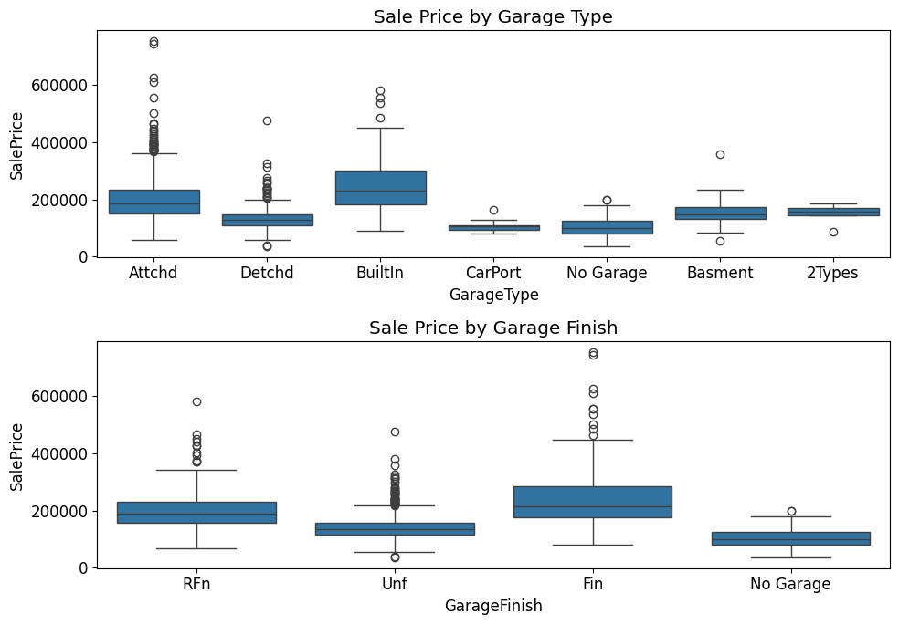

```python
# Creating graphs for Garage Type and Finish

fig, axes = plt.subplots(2, 1, figsize=(10, 7))

sns.boxplot(x='GarageType', y='SalePrice', data=data, ax=axes[0])
sns.boxplot(x='GarageFinish', y='SalePrice', data=data, ax=axes[1])

axes[0].set_title('Sale Price by Garage Type')
axes[1].set_title('Sale Price by Garage Finish')

plt.tight_layout()
plt.show()
```

```python
# Attempting to assign values to Garage Finish

data['GarageFinish'] = data['GarageFinish'].replace('No Garage', 1)

data['GarageFinish'] = data['GarageFinish'].replace('Unf',2)

data['GarageFinish'] = data['GarageFinish'].replace('RFn',3)

data['GarageFinish'] = data['GarageFinish'].replace('Fin',4)

print(data['GarageFinish'].unique())

# Attempting to assign values to Garage Type

data['GarageType'] = data['GarageType'].replace('No Garage',1)

data['GarageType'] = data['GarageType'].replace('CarPort',2)

data['GarageType'] = data['GarageType'].replace('Detchd',3)

data['GarageType'] = data['GarageType'].replace('Basment',4)

data['GarageType'] = data['GarageType'].replace('2Types',5)

data['GarageType'] = data['GarageType'].replace('Attchd',6)

data['GarageType'] = data['GarageType'].replace('BuiltIn',7)

print(data['GarageType'].unique())
```

```
[3 2 4 1]
[6 3 7 2 1 4 5]
```

```python
# Testing Correlations of all Garage related variables

print(f'Garage Area Correlation: {data["SalePrice"].corr(data["GarageArea"])}')

print(f'Garage Quality Correlation: {data["SalePrice"].corr(data["GarageQual"])}')

print(f'Garage Condition Correlation: {data["SalePrice"].corr(data["GarageCond"])}')

print(f'Garage Finish Correlation: {data['SalePrice'].corr(data['GarageFinish'])}')

print(f'Garage Type Correlation: {data['SalePrice'].corr(data['GarageType'])}')

print(f'Garage Year Correlation: {data['SalePrice'].corr(data['GarageYrBlt'])}')

print(f'Garage Cars Correlation: {data['SalePrice'].corr(data['GarageCars'])}')
```

```
Garage Area Correlation: 0.6234228990077114
Garage Quality Correlation: 0.2738786352160778
Garage Condition Correlation: 0.263230492793312
Garage Finish Correlation: 0.5498090492717976
Garage Type Correlation: 0.48992659823627144
Garage Year Correlation: 0.26141263031447626
Garage Cars Correlation: 0.6404729026424087
```

As stated during the Fireplace section, I will just choose the highest correaltion to keep the process and dataset more simple. Thus I will keep only Garage cars and delete the rest of the garage columns.

```python
data = data.drop(columns=['GarageArea'])

data = data.drop(columns=['GarageQual'])

data = data.drop(columns=['GarageCond'])

data = data.drop(columns=['GarageFinish'])

data = data.drop(columns=['GarageType'])

data = data.drop(columns=['GarageYrBlt'])

data.shape
```

```
(1459, 69)
```

## Basement Variables

Since all the Basement variables are missing similar amounts of data points they are likely missing the same data points for the most parts. The data points missing are from the following variables:

- BsmtQual: Height of the basement
- BsmtCond: General condition of the basement
- BsmtExposure: Walkout or garden level basement walls
- BsmtFinType1: Quality of basement finished area
- BsmtFinType2: Quality of second finished area (if present)

Since BsmtFinType2 and BsmtExposure have one more additional missing value than the rest of the variables I will first try to isolate these additonal missing points and see if it's missing at random or if there's a reason

```python
extraBsmt_FinType2 = data[(data['BsmtFinType2'].isnull()) & (data['TotalBsmtSF'] > 0)]

print(extraBsmt_FinType2.shape)
print()

extraBsmt_Exposure = data[(data['BsmtExposure'].isnull()) & (data['TotalBsmtSF'] > 0)]

print(extraBsmt_Exposure.shape)
print()

print(extraBsmt_FinType2[['BsmtQual','BsmtCond','BsmtExposure','BsmtFinType1','BsmtFinSF1','BsmtFinType2','BsmtFinSF2','BsmtUnfSF','TotalBsmtSF']])
print()

print(extraBsmt_Exposure[['BsmtQual','BsmtCond','BsmtExposure','BsmtFinType1','BsmtFinSF1','BsmtFinType2','BsmtFinSF2','BsmtUnfSF','TotalBsmtSF']])
```

```
(1, 69)

(1, 69)

    BsmtQual BsmtCond BsmtExposure BsmtFinType1  BsmtFinSF1 BsmtFinType2  \
332       Gd       TA           No          GLQ        1124          NaN

     BsmtFinSF2  BsmtUnfSF  TotalBsmtSF
332         479       1603         3206

    BsmtQual BsmtCond BsmtExposure BsmtFinType1  BsmtFinSF1 BsmtFinType2  \
948       Gd       TA          NaN          Unf           0          Unf

     BsmtFinSF2  BsmtUnfSF  TotalBsmtSF
948           0        936          936
```

Since it seems to be missing at random I will just drop these data points since it shouldn't change the overall data too much

```python
data.drop(data[(data['BsmtFinType2'].isnull()) & (data['TotalBsmtSF'] > 0)].index, inplace=True)

data.drop(data[(data['BsmtExposure'].isnull()) & (data['TotalBsmtSF'] > 0)].index, inplace=True)
```

Now that each Basement variable should now be missing the same amount of data points. I will check if the missing data points are the same using the same method as the missing Garage data points

```python
noBsmt = data[data['TotalBsmtSF']==0]

print(f"The Shape of data with no basement: {noBsmt.shape}")

noBsmt_Qual = data[(data['BsmtQual'].isnull()) & (data['TotalBsmtSF'] == 0)]

print(f"The Shape of data with no basement and no basement quality: {noBsmt_Qual.shape}")

noBsmt_Cond = data[(data['BsmtCond'].isnull()) & (data['TotalBsmtSF'] == 0)]

print(f"The Shape of data with no basement and no basement condition: {noBsmt_Cond.shape}")

noBsmt_FinType1 = data[(data['BsmtFinType1'].isnull()) & (data['TotalBsmtSF'] == 0)]

print(f"The Shape of data with no basement and no quality of basement finished area: {noBsmt_FinType1.shape}")

noBsmt_FinType2 = data[(data['BsmtFinType2'].isnull()) & (data['TotalBsmtSF'] == 0)]

print(f"The Shape of data with no basement and no quality of second finished area: {noBsmt_FinType2.shape}")

noBsmt_Exposure = data[(data['BsmtExposure'].isnull()) & (data['TotalBsmtSF'] == 0)]

print(f"The Shape of data with no basement and no exposure: {noBsmt_Exposure.shape}")
```

```
The Shape of data with no basement: (37, 69)
The Shape of data with no basement and no basement quality: (37, 69)
The Shape of data with no basement and no basement condition: (37, 69)
The Shape of data with no basement and no quality of basement finished area: (37, 69)
The Shape of data with no basement and no quality of second finished area: (37, 69)
The Shape of data with no basement and no exposure: (37, 69)
```

They appear to be all missing the same points so I will now replace these points with 'No Basement'.

```python
# Taking out the 'NaN' Elements and replacing with 'No Basement'
data['BsmtQual'] = data['BsmtQual'].fillna('No Basement')

# Taking out the 'NaN' Elements and replacing with 'No Basement'
data['BsmtCond'] = data['BsmtCond'].fillna('No Basement')

# Taking out the 'NaN' Elements and replacing with 'No Basement'
data['BsmtFinType1'] = data['BsmtFinType1'].fillna('No Basement')

# Taking out the 'NaN' Elements and replacing with 'No Basement'
data['BsmtFinType2'] = data['BsmtFinType2'].fillna('No Basement')

# Taking out the 'NaN' Elements and replacing with 'No Basement'
data['BsmtExposure'] = data['BsmtExposure'].fillna('No Basement')
```

### Testing Basement Correlation

```python
# Looking at categorical values to see if there are inherent numercial interpretations to convert categorical to quantitative
print(data['BsmtQual'].unique())

print(data['BsmtCond'].unique())

print(data['BsmtFinType1'].unique())

print(data['BsmtFinType2'].unique())

print(data['BsmtExposure'].unique())
```

```
['Gd' 'TA' 'Ex' 'No Basement' 'Fa']
['TA' 'Gd' 'No Basement' 'Fa' 'Po']
['GLQ' 'ALQ' 'Unf' 'Rec' 'BLQ' 'No Basement' 'LwQ']
['Unf' 'BLQ' 'No Basement' 'ALQ' 'Rec' 'LwQ' 'GLQ']
['No' 'Gd' 'Mn' 'Av' 'No Basement']
```

I will start with Basement Quality, Condition, and Exposure since these are the most easily converted to numerical figure

```python
# Converting Basement Quality to Numerical representations
data['BsmtQual'] = data['BsmtQual'].replace('No Basement', 1)

data['BsmtQual'] = data['BsmtQual'].replace('Fa', 2)

data['BsmtQual'] = data['BsmtQual'].replace('TA', 3)

data['BsmtQual'] = data['BsmtQual'].replace('Gd', 4)

data['BsmtQual'] = data['BsmtQual'].replace('Ex', 5)

print(data['BsmtQual'].unique())

# Converting Basement Quality to Numerical representations

data['BsmtCond'] = data['BsmtCond'].replace('No Basement', 1)

data['BsmtCond'] = data['BsmtCond'].replace('Po', 2)

data['BsmtCond'] = data['BsmtCond'].replace('Fa', 3)

data['BsmtCond'] = data['BsmtCond'].replace('TA', 4)

data['BsmtCond'] = data['BsmtCond'].replace('Gd', 5)

print(data['BsmtCond'].unique())

# Converting Basement Exposure to Numerical representations

data['BsmtExposure'] = data['BsmtExposure'].replace('No Basement', 1)

data['BsmtExposure'] = data['BsmtExposure'].replace('No', 1)

data['BsmtExposure'] = data['BsmtExposure'].replace('Mn', 2)

data['BsmtExposure'] = data['BsmtExposure'].replace('Av', 3)

data['BsmtExposure'] = data['BsmtExposure'].replace('Gd', 4)

print(data['BsmtExposure'].unique())
```

```
[4 3 5 1 2]
[4 5 1 3 2]
[1 4 2 3]
```

I will now look at a graph for both Basement Finihs types to see if there is a easy way to convert these to numerical values.

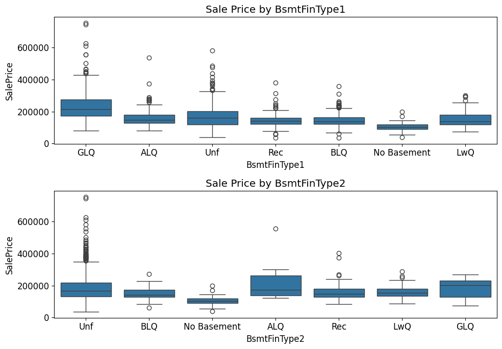

```python
# Creating graphs for Garage Type and Finish

fig, axes = plt.subplots(2, 1, figsize=(10, 7))

sns.boxplot(x='BsmtFinType1', y='SalePrice', data=data, ax=axes[0])
sns.boxplot(x='BsmtFinType2', y='SalePrice', data=data, ax=axes[1])

axes[0].set_title('Sale Price by BsmtFinType1')
axes[1].set_title('Sale Price by BsmtFinType2')

plt.tight_layout()
plt.show()
```

Since there doesn't seem to be an apparent way to change these categories to numerical values I can assume that this means there isn't giong to be a strong correlation so I will just delete these categories with the rest later

```python
# Comparing different Basement Correlations

print(f'Basement Area Correlation: {data["SalePrice"].corr(data["TotalBsmtSF"])}')

print(f'Basement Quality Correlation: {data["SalePrice"].corr(data["BsmtQual"])}')

print(f'Basement Condition Correlation: {data["SalePrice"].corr(data["BsmtCond"])}')

print(f'Basement Exposure Correlation: {data["SalePrice"].corr(data["BsmtExposure"])}')
```

```
Basement Area Correlation: 0.6150306002600917
Basement Quality Correlation: 0.6229992286583587
Basement Condition Correlation: 0.21263348456282272
Basement Exposure Correlation: 0.3627801753411015
```

```python
data = data.drop(columns=['BsmtFinType1'])

data = data.drop(columns=['BsmtFinType2'])

data  = data.drop(columns=['BsmtFinSF1'])

data  = data.drop(columns=['BsmtFinSF2'])

data = data.drop(columns=['TotalBsmtSF'])

data = data.drop(columns=['BsmtUnfSF'])

data = data.drop(columns=['BsmtExposure'])

data = data.drop(columns=['BsmtCond'])

data.shape
```

```
(1457, 61)
```

## Masonry Veneer

I will first start with when Veneer Area is 'NaN' since this has less missing values

```python
# Create a dataframe of the data points where Masonry Veneer Area is missing
missing_MsnVnr = data[data['MasVnrArea'].isnull()]

# Check if there is any information about the Veneer type for these data points
print(missing_MsnVnr[['MasVnrType']])
```

```
     MasVnrType
234         NaN
529         NaN
650         NaN
936         NaN
973         NaN
977         NaN
1243        NaN
1278        NaN
```

Since there is no data available for either Veneer area or Veneer type, it can be assumed that there is no Veneer so we can change Veneer Area to 0

```python
data['MasVnrArea'] = data['MasVnrArea'].fillna(0)
```

Now I can move onto Veneer Type

```python
# Create a dataset where Veneer type is null
missing_MsnVnr = data[data['MasVnrType'].isnull()]
# Create a dataset where Veneer Area is 0 (No Veneer)
no_MsnVnr = data[data['MasVnrArea']==0]

print(missing_MsnVnr.shape)
print(no_MsnVnr.shape)
```

```
(871, 61)
(868, 61)
```

Since the shapes don't line up I have to do a little more looking into each variable to figure out what the discrepancy is.

I will first handle the easy case in which Veneer area is 0 and Veneer type is null

```python
missing_MsnVnr = data[(data['MasVnrArea']==0) & (data['MasVnrType'].isnull())]
print(missing_MsnVnr.shape)
```

```
(866, 61)
```

```python
# Replacing all the data points which meet the conditions and replace the 'NaN' with 'No Veneer'
data.loc[(data['MasVnrArea'] == 0) & (data['MasVnrType'].isnull()), 'MasVnrType'] = 'No Veneer'
```

The second case is which the Veneer area is greater than 0 and Veneer type is null

```python
missing_MsnVnr = data[(data['MasVnrArea']>0) & (data['MasVnrType'].isnull())]
print(missing_MsnVnr.shape)
```

```
(5, 61)
```

```python
# Getting the Neighborhood of those that have a veneer but no type available
print(missing_MsnVnr[['Id', 'Neighborhood', 'MasVnrArea']])
```

```
        Id Neighborhood  MasVnrArea
624    625       NWAmes       288.0
773    774        NAmes         1.0
1230  1231       Sawyer         1.0
1300  1301      Gilbert       344.0
1334  1335       BrDale       312.0
```

```python
# Creating a dataframe of just the NWAmes houses
NWames = data[data['Neighborhood'] == 'NWAmes']
# Finding what Veneer types show up and how many of each Veneer type shows up
print(NWames['MasVnrType'].value_counts())
```

```
MasVnrType
BrkFace      50
No Veneer    19
Stone         3
Name: count, dtype: int64
```

Now that I know the frequency of each venner type in the neighborhood I can most likely assume it is a Brick Face Veneer since Brick Face is the most common, but to double check I will see if the Veneer Area changes what type I should choose to replace the 'NaN'. I will check this by creating a diagram of each veneer type and adding the Veneer Area of the 'target' to see if there is a more likely option for the veneer type

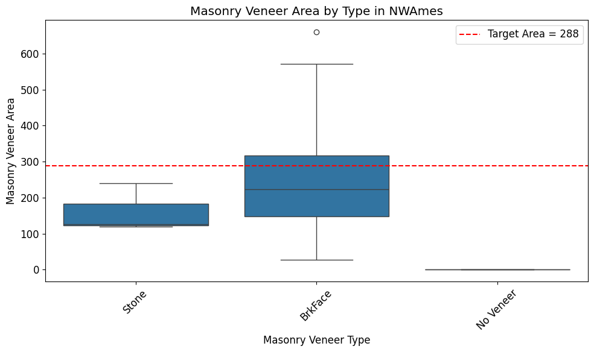

```python
# Create the boxplot
plt.figure(figsize=(10, 6))
sns.boxplot(x='MasVnrType', y='MasVnrArea', data=NWames)

# Add titles and labels
plt.title('Masonry Veneer Area by Type in NWAmes')
plt.xlabel('Masonry Veneer Type')
plt.ylabel('Masonry Veneer Area')
plt.xticks(rotation=45)
plt.tight_layout()

# Add target line
plt.axhline(y=288, color='red', linestyle='--', label='Target Area = 288')
plt.legend()

plt.show()
```

```python
# Replacing the missing Veneer type with the likely type
data.loc[(data['Id'] == 625), 'MasVnrType'] = 'BrkFace'
```

I will repeat this process with the rest of the houses in the list

```python
# Creating a dataframe of just the NWAmes houses
NAmes = data[data['Neighborhood'] == 'NAmes']
# Finding what Veneer types show up and how many of each Veneer type shows up
print(NAmes['MasVnrType'].value_counts())
```

```
MasVnrType
No Veneer    122
BrkFace       86
Stone          9
BrkCmn         7
Name: count, dtype: int64
```

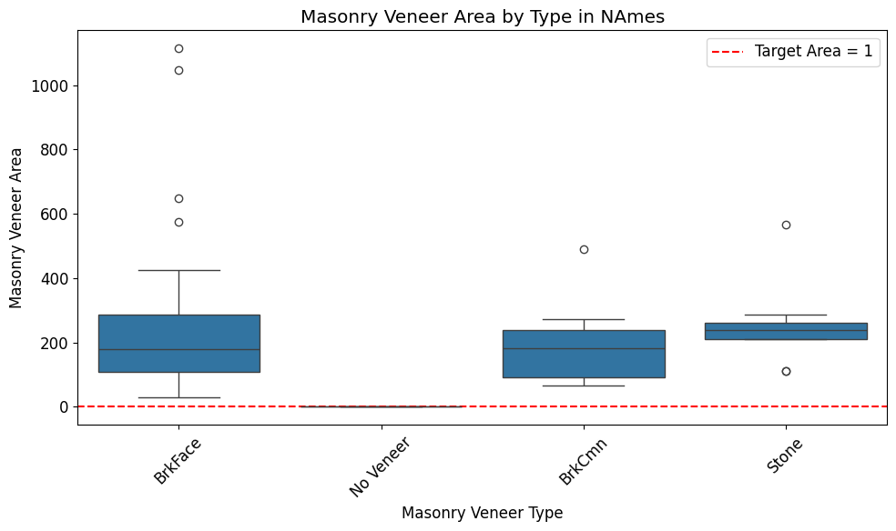

```python
# Create the boxplot
plt.figure(figsize=(10, 6))
sns.boxplot(x='MasVnrType', y='MasVnrArea', data=NAmes)

# Add titles and labels
plt.title('Masonry Veneer Area by Type in NAmes')
plt.xlabel('Masonry Veneer Type')
plt.ylabel('Masonry Veneer Area')
plt.xticks(rotation=45)
plt.tight_layout()

# Add target line
plt.axhline(y=1, color='red', linestyle='--', label='Target Area = 1')
plt.legend()

plt.show()
```

Since the Veneer area is so small I will check to see if there is any other veneer with area of 1 to help make the choice

```python
smallVnr = data[data['MasVnrArea'] == 1]
print(smallVnr.shape)
```

```
(2, 61)
```

Since theres only two in the whole dataset, and those two are the data points Im trying to fix I can assume it was meant to be zero and I will change the area to 0 and type to 'No Veneer'

```python
data.loc[(data['Id'] == 774), 'MasVnrArea'] = 0
data.loc[(data['Id'] == 774), 'MasVnrType'] = 'No Veneer'

data.loc[(data['Id'] == 1231), 'MasVnrArea'] = 0
data.loc[(data['Id'] == 1231), 'MasVnrType'] = 'No Veneer'
```

Next house

```python
# Creating a dataframe of just the NWAmes houses
Gilbert = data[data['Neighborhood'] == 'Gilbert']
# Finding what Veneer types show up and how many of each Veneer type shows up
print(Gilbert['MasVnrType'].value_counts())
```

```
MasVnrType
No Veneer    58
BrkFace      18
Stone         2
Name: count, dtype: int64
```

[figure not shown]

```python
# Create the boxplot
plt.figure(figsize=(10, 6))
sns.boxplot(x='MasVnrType', y='MasVnrArea', data=NAmes)

# Add titles and labels
plt.title('Masonry Veneer Area by Type in NAmes')
plt.xlabel('Masonry Veneer Type')
plt.ylabel('Masonry Veneer Area')
plt.xticks(rotation=45)
plt.tight_layout()

# Add target line
plt.axhline(y=344, color='red', linestyle='--', label='Target Area = 344')
plt.legend()

plt.show()
```

```python
# Replacing the missing Veneer type with the likely type
data.loc[(data['Id'] == 1301), 'MasVnrType'] = 'BrkFace'
```

Final house

```python
# Creating a dataframe of just the NWAmes houses
BrDale = data[data['Neighborhood'] == 'BrDale']
# Finding what Veneer types show up and how many of each Veneer type shows up
print(BrDale['MasVnrType'].value_counts())
```

```
MasVnrType
BrkFace    15
Name: count, dtype: int64
```

```python
# Replacing the missing Veneer type with the likely type
data.loc[(data['Id'] == 1335), 'MasVnrType'] = 'BrkFace'
```

### Testing Veneer Correlation

Based from above it doesn't seem that Veneer type has too much correlation with other variables so I will just check Veneer Area and drop the veneer type

```python
data = data.drop(columns=['MasVnrType'])

print(f'Masonry Veneer Area Correlation: {data["SalePrice"].corr(data["MasVnrArea"])}')
```

```
Masonry Veneer Area Correlation: 0.4721028847777878
```

## Final Missing Data Points

As I learned from the Pool Correlation, when there are too many missing points the correlation isn't that high with sale price so I can just drop the columns with too many missing values

```python
missing_data = data.isnull().sum()
missing_data = missing_data.sort_values(ascending=False)
missing_data = missing_data[missing_data > 0]
missing_data
```

|  | 0 |
| --- | --- |
| Alley | 1366 |
| Fence | 1176 |
| LotFrontage | 259 |

**dtype:** int64

Thus I will just drop Alley and Fence columns

```python
data = data.drop(columns=['Alley'])

data = data.drop(columns=['Fence'])

data.shape
```

```
(1457, 58)
```

Before I embark on cleaning the Lot Frontage data I will first see if the two Lot variables have high predictive power, if not I will just drop these columns

```python
print(f'Lot Frontage Correlation: {data['SalePrice'].corr(data['LotFrontage'])}')

print(f'Lot Area Correlation: {data['SalePrice'].corr(data['LotArea'])}')
```

```
Lot Frontage Correlation: 0.3514993654682095
Lot Area Correlation: 0.26395544844356883
```

Since both of these correlations don't seem to have high predictive power I will just drop these variables

```python
data = data.drop(columns=['LotFrontage'])

data = data.drop(columns=['LotArea'])

data.shape
```

```
(1457, 56)
```

# Further Simplifying Dataset

To help simplify the data down even more, I will just look at the numerical categories. Although I would like to convert each categorical to numerical if possible, I do not have the time to achieve this goal. So instead, to hurry up the process and began working on the learning model I will just look into the numerical categories.

```python
simple_data = data.select_dtypes(include='number')
```

I will now take the correlation of each variable and just look how each feature correlates with sale price and choose any feature that has, in my opinion, high predictive power. For simplicity purposes I will choose any features with a correlation > |0.5|

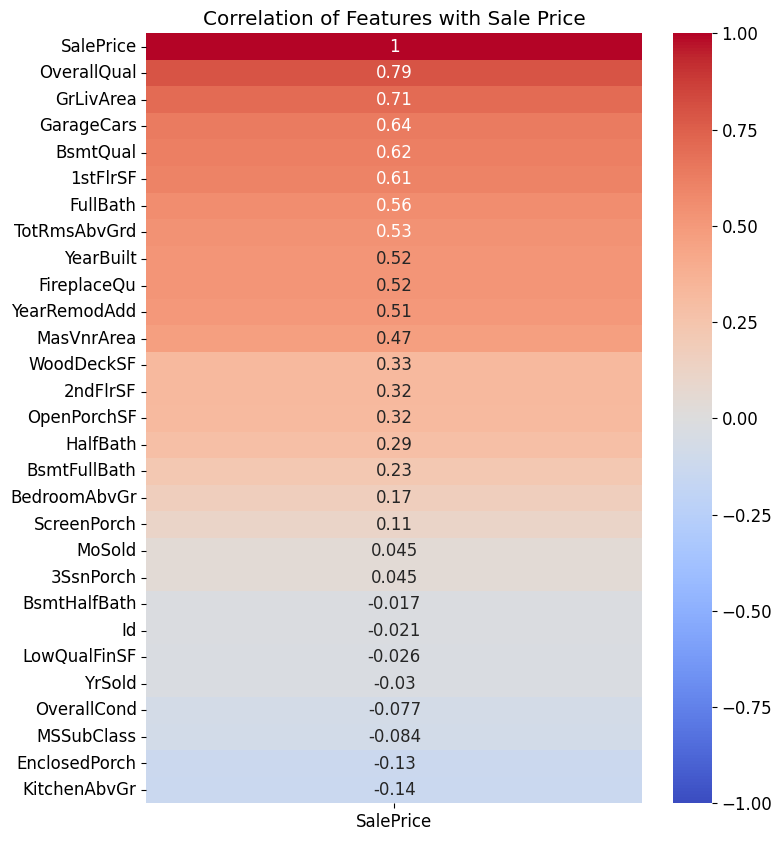

```python
corr = simple_data.corr()

plt.figure(figsize=(8, 10))
sns.heatmap(corr[['SalePrice']].sort_values(by='SalePrice', ascending=False),
            annot=True, cmap='coolwarm', vmin=-1, vmax=1)
plt.title('Correlation of Features with Sale Price')
plt.show()
```

Thus I will only choose the following features:

- Year Remodel
- Fireplace Quality
- Year Built
- Total Rooms Above Ground
- Full Bath
- 1st Floor SQ FT
- Basement Qual
- Garage Cars
- Above Ground Living Area
- Overall Qual

# Training Model

Using the top 10 correlation scores, I will use these variables to train the model in hopes of prediciting the sale price.

```python
# Choosing variables and target variables
X = data[['OverallQual', 'GrLivArea', 'GarageCars','BsmtQual','1stFlrSF','FullBath','TotRmsAbvGrd','YearBuilt','FireplaceQu','YearRemodAdd']]
y = data['SalePrice']

print("Feature matrix X shape:", X.shape)
print("Target vector y shape:", y.shape)

# Creating Train and Test variables
X_train, X_test, y_train, y_test = train_test_split( X, y, test_size=0.2, random_state=10)

print(f"Training set size: {len(X_train)} samples")
print(f"Test set size: {len(X_test)} samples")
```

```
Feature matrix X shape: (1457, 10)
Target vector y shape: (1457,)
Training set size: 1165 samples
Test set size: 292 samples
```

```python
#Scaling Data

scaler = StandardScaler()
X_train_scaled = scaler.fit_transform(X_train)

X_test_scaled = scaler.transform(X_test)

X_train_scaled = pd.DataFrame(X_train_scaled, columns=X.columns, index=X_train.index)
X_test_scaled = pd.DataFrame(X_test_scaled, columns=X.columns, index=X_test.index)
```

```python
# Calculate correlation using only training data
train_data = X_train.copy()
train_data['Sales'] = y_train.values

correlation_matrix = train_data.corr()
print("Correlation Matrix (Training Data Only):")
print(correlation_matrix.round(3))
```

```
Correlation Matrix (Training Data Only):
              OverallQual  GrLivArea  GarageCars  BsmtQual  1stFlrSF  \
OverallQual         1.000      0.602       0.600     0.670     0.476
GrLivArea           0.602      1.000       0.478     0.367     0.548
GarageCars          0.600      0.478       1.000     0.477     0.457
BsmtQual            0.670      0.367       0.477     1.000     0.327
1stFlrSF            0.476      0.548       0.457     0.327     1.000
FullBath            0.557      0.636       0.479     0.446     0.388
TotRmsAbvGrd        0.439      0.828       0.372     0.220     0.406
YearBuilt           0.573      0.203       0.533     0.662     0.287
FireplaceQu         0.492      0.474       0.374     0.342     0.425
YearRemodAdd        0.556      0.304       0.419     0.546     0.244
Sales               0.795      0.729       0.634     0.636     0.629

              FullBath  TotRmsAbvGrd  YearBuilt  FireplaceQu  YearRemodAdd  \
OverallQual      0.557         0.439      0.573        0.492         0.556
GrLivArea        0.636         0.828      0.203        0.474         0.304
GarageCars       0.479         0.372      0.533        0.374         0.419
BsmtQual         0.446         0.220      0.662        0.342         0.546
1stFlrSF         0.388         0.406      0.287        0.425         0.244
FullBath         1.000         0.545      0.479        0.289         0.449
TotRmsAbvGrd     0.545         1.000      0.098        0.358         0.203
YearBuilt        0.479         0.098      1.000        0.239         0.579
FireplaceQu      0.289         0.358      0.239        1.000         0.205
YearRemodAdd     0.449         0.203      0.579        0.205         1.000
Sales            0.566         0.540      0.527        0.522         0.511

              Sales
OverallQual   0.795
GrLivArea     0.729
GarageCars    0.634
BsmtQual      0.636
1stFlrSF      0.629
FullBath      0.566
TotRmsAbvGrd  0.540
YearBuilt     0.527
FireplaceQu   0.522
YearRemodAdd  0.511
Sales         1.000
```

```python
# Create and train the model on scaled data
model = LinearRegression()
model.fit(X_train_scaled, y_train)
```

```
LinearRegression()
```

```python
# Extract coefficients
intercept = model.intercept_
coefficients = model.coef_

# Create a DataFrame for easy viewing
coef_df = pd.DataFrame({
    'Feature': X.columns,
    'Coefficient': coefficients
})

print(f"Intercept (b₀): {intercept:.4f}")
print("\nCoefficients:")
print(coef_df)
```

```
Intercept (b₀): 180767.6429

Coefficients:
        Feature   Coefficient
0   OverallQual  22455.359289
1     GrLivArea  31508.833673
2    GarageCars   7489.409905
3      BsmtQual  11017.662910
4      1stFlrSF  14633.205320
5      FullBath  -6001.739458
6  TotRmsAbvGrd  -3187.450881
7     YearBuilt   7363.463116
8   FireplaceQu   3469.850770
9  YearRemodAdd   4798.327102
```

```python
# Performance on training set
y_train_pred = model.predict(X_train_scaled)
r2_train = r2_score(y_train, y_train_pred)
mse_train = mean_squared_error(y_train, y_train_pred)
rmse_train = np.sqrt(mse_train)

print("Training Set Performance:")
print(f"  R-squared: {r2_train:.4f}")
print(f"  MSE: {mse_train:.4f}")
print(f"  RMSE: {rmse_train:.4f}")
```

```
Training Set Performance:
  R-squared: 0.8029
  MSE: 1283767330.5737
  RMSE: 35829.6990
```

```python
# Performance on test set
y_test_pred = model.predict(X_test_scaled)
r2_test = r2_score(y_test, y_test_pred)
mse_test = mean_squared_error(y_test, y_test_pred)
rmse_test = np.sqrt(mse_test)

print("Test Set Performance:")
print(f"  R-squared: {r2_test:.4f}")
print(f"  MSE: {mse_test:.4f}")
print(f"  RMSE: {rmse_test:.4f}\n")
```

```
Test Set Performance:
  R-squared: 0.6474
  MSE: 1944898707.0223
  RMSE: 44101.0057
```

# Reflection

For the data wrangling and cleaning part of this project, I am content with many of my methods and approaches to clean the dataset. One improvement I thought of while working through the cleaning, throughout the process I used different methods to either erase or replace data. While this was a good for discovering and trying new ways to clean data, I think for future projects I should make a more strict protocol when it comes to missing data that way each missing point is handled in the same way because right now my methods were a little diverse.

For the data training I left much to be desired. If I had more time I would want to go and try to convert all the categorical values to numerical values if possible and also have a more rigorous method of choosing the variables which the model was trained on. The error of my model is much higher than I desired. For my next project I plan on focusing more on the training side in hopes of seeing improvement and more understanding on that front.

# Converting to HTML

```python
# Install nbconvert if needed
! pip install nbconvert
# Convert this notebook to HTML
! jupyter nbconvert --to html "/content/drive/MyDrive/Foundations of Data Science/Projects/Garzon - Project 1 - Clean and Train House Dataset.ipynb" --output project
```